# Caffinated Classification

Data Analysis Final Project (R_Markdown)

Sonny Sparks & Sidney Davis

4/27/22

# **Project Description:**

If you choose to work on a classification problem, build multiple classifiers using all of the techniques we have discussed (decision trees, k-nearest neighbors, naive Bayes, neural net-works, support vector machines, random forests, bagging, and boosting). All models built should be tuned and thoroughly assessed using appropriate metrics. Classifiers can be assessed with classification accuracy, sensitivity, specificity, precision, recall, and area under the ROC curve.

```r
################################################################################
caffeine <- read.csv("/Users/sonnysparks/Documents/Tarleton Spring 22'/Data Analysis/Data_Analysis_Final_Project/caffeine.csv")
colnames(caffeine)=c("Drink","Volume","Calories","Caffeine","Caffperoz","Type")
View(caffeine)

caffeine$Type=as.factor(caffeine$Type)
caffeine = subset(caffeine,select= -Drink)

################################################################################
### Split Train / Test Data ###
################################################################################
train=sample(nrow(caffeine),round(0.7*nrow(caffeine),0))
caffeine.train.data=caffeine[train,]
caffeine.test.data=caffeine[-train,]
```

Since this is done in a R-Markdown document, we have to carry everything with us, such as function, library and data set. This is the reason the data is read in this way from my personal file path. Our data set is of various drinks and their caffeine levels. The purpose of this project is to classify the type of drink (Energy Drink, Coffee, ect.) based on its volume, caffeine per oz, and calories. Also in this section we made the necessary train/test splits that will be used in each model to come.

# **Decision Trees:**

## *R-Part -*

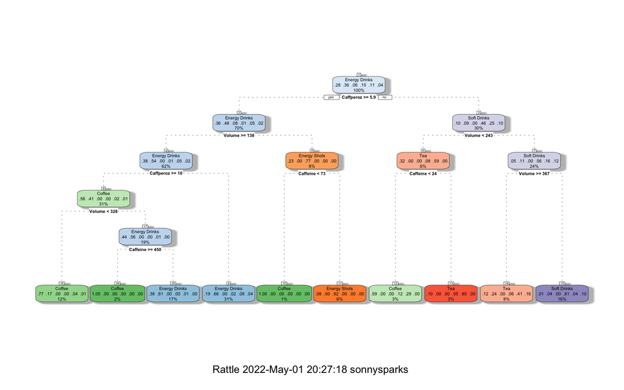

```r
Caf.rpar=rpart(Type~Volume+Calories+Caffeine+Caffperoz,data=caffeine)
fancyRpartPlot(Caf.rpar)
```

```r
# Train Accuracy
metrics(caffeine.train.data$Type, predict(Caf.rpar,newdata=caffeine.train.data, type="class"))
```

```
$matrix
               predy
y               Coffee Energy Drinks Energy Shots Soft Drinks Tea Water
  Coffee            68            54            1           0   5     0
  Energy Drinks      8           132            0           3   9     0
  Energy Shots       0             0           22           0   0     0
  Soft Drinks        1             3            0          51   2     0
  Tea                4            11            0           2  32     0
  Water              1             6            0           8   4     0

$accuracy
[1] 0.7142857

$error
[1] 0.2857143

$Sensitivity
[1] 0.557377

$Specificity
[1] 0.9428571

$Precision
[1] 0.8947368
```

```r
# Test Accuracy
metrics(caffeine.test.data$Type, predict(Caf.rpar,newdata=caffeine.test.data, type="class"))
```

```
$matrix
               predy
y               Coffee Energy Drinks Energy Shots Soft Drinks Tea Water
  Coffee            16            23            2           1   3     0
  Energy Drinks      4            59            0           1   3     0
  Energy Shots       0             0           14           0   0     0
  Soft Drinks        1             1            0          29   2     0
  Tea                4             6            0           2   5     0
  Water              0             1            0           2   4     0

$accuracy
[1] 0.6721311

$error
[1] 0.3278689

$Sensitivity
[1] 0.4102564

$Specificity
[1] 0.9365079

$Precision
[1] 0.8
```